# Cleaning up the ancestry terms

#### Race + ethnicity info:

```r
raceEthnicity <- allSRAClean[!is.na(allSRAClean$RACE) & !is.na(allSRAClean$ETHNICITY),]
raceEthnicityTable <- as.data.frame(table(raceEthnicity$RACE, raceEthnicity$ETHNICITY))
raceEthnicityTable[raceEthnicityTable$Freq > 0,]
```

```
##                                  Var1                      Var2 Freq
## 1                                  AA                        AA   87
## 66                                 AS                        AS    5
## 127                             Asian                     asian   39
## 240                       yellow race                     Asian   44
## 252         Black or African American Black or African American    1
## 315                              CAUC                      CAUC  164
## 391               Not Hispanic/Latino                 Caucasian   12
## 413                             white                 Caucasian   74
## 474                             White                 Caucasoid   24
## 490                             Black                   English   10
## 578                                R1                Ethnicity1    1
## 639                               R10               Ethnicity10    1
## 700                               R11               Ethnicity11    1
## 761                               R12               Ethnicity12    1
```

[output cut: 95 more lines]

Seems like a lot of the overlaps are people who are using this correctly in the US style - a racial term and then hispanic or not. Then there’s the ones that are confused, eg, 304 samples labelled as EUR in both columns, or ‘White German’ etc

#### Other descriptor pairs:

```r
racePopulation <- allSRAClean[!is.na(allSRAClean$RACE) & !is.na(allSRAClean$Population),]
racePopulationTable <- as.data.frame(table(racePopulation$RACE, racePopulation$Population))
racePopulationTable[racePopulationTable$Freq > 0,]
```

```
##                         Var1             Var2 Freq
## 11               yellow race            Adult    6
## 13                     black        Brazilian    3
## 19                     pardo        Brazilian    2
## 20                     white        Brazilian   10
## 33               yellow race       Cord blood    6
## 37                 Caucasian           Danish   16
## 45                     ASIAN               GB  208
## 47 BLACK OR AFRICAN AMERICAN               GB  176
## 51                     OTHER               GB  142
## 54                     WHITE               GB 1777
## 60                   missing          missing   12
## 72            not applicable   not applicable   11
## 88               yellow race Peripheral blood   17
## 99               yellow race     Tumor tissue   15
```

```r
ethnicityPopulation <- allSRAClean[!is.na(allSRAClean$ETHNICITY) & !is.na(allSRAClean$Population),]
ethnicityPopulationTable <- as.data.frame(table(ethnicityPopulation$ETHNICITY, ethnicityPopulation$Population))
ethnicityPopulationTable[ethnicityPopulationTable$Freq > 0,]
```

```
##                      Var1             Var2 Freq
## 1                   Asian            Adult    6
## 9               caucasian        Brazilian   24
## 15                  Asian       Cord blood    6
## 24     HISPANIC OR LATINO               GB  160
## 27 NOT HISPANIC OR LATINO               GB 1900
## 28           NOT REPORTED               GB  227
## 32                missing          missing   12
## 40         not applicable   not applicable   11
## 43                  Asian Peripheral blood   17
## 50                  Asian     Tumor tissue   15
```

Race population is unhelpful, and the bulk of it from the GB study, where GB is a cell type, not a population descriptor; those samples all have hispanic/not hispanic designations too. Also the ethnicity/population combo.

### Updating the descriptors:

On the basis of all of that and a lot of discussions, we boil things down to the following descriptors, which we’re gonna spend some time getting to:

1. finalRace - correspond to US racial terms. Cleaned up below but built initially from columns `RACE`, `race.ethnicity`, `DONOR_ETHNICITY`, `primary_race` and `reported_race`. The major column here is `RACE`.
2. finalGeography - tries to capture geographic origin/ancestry (not genetic). Also cleaned up below, but built initially from info in columns `ETHNICITY`, `ancestry` and `Population`. The major column here is `ETHNICITY` but there’ll be some reassignment of terms to other columns as we go.
3. hispanic - true/false column for those who reported hispanic/not hispanic, regardless of what column

We begin by merging the multiple columns into `mergedRace` and `mergedGeography`, this will be the basis of all cleaning downstream:

```r
# This column is filled in order: RACE, if empty, race.ethnicity, if empty reported_race, etc etc... There's no overlap between these, from above, so we know it's all good.
allSRAClean$mergedRace <- coalesce(allSRAClean$RACE, allSRAClean$race.ethnicity) %>%
  coalesce(., allSRAClean$reported_race) %>%
  coalesce(., allSRAClean$DONOR_ETHNICITY) %>%
  coalesce(., allSRAClean$primary_race)

# In order of importance: ancestry, if empty, Population, if empty ETHNICITY
allSRAClean$mergedGeography <- coalesce(allSRAClean$ancestry, allSRAClean$Population) %>%
  coalesce(., allSRAClean$ETHNICITY)
```

Some quick QC on the new columns… FALSE is the number of rows with some sort of annotation in these new columns, although some of them are mistakes at this point, the bulk of FALSE/FALSE is gonna be hispanic/latino info and/or that cursed GB dataset

```r
table(is.na(allSRAClean$mergedGeography))
```

```
##
## FALSE  TRUE
## 18872  8297
```

```r
table(is.na(allSRAClean$mergedRace))
```

```
##
## FALSE  TRUE
## 15303 11866
```

```r
# And how much redundancy?
table(is.na(allSRAClean$mergedGeography), is.na(allSRAClean$mergedRace)) #
```

```
##
##         FALSE  TRUE
##   FALSE  7006 11866
##   TRUE   8297     0
```

```r
# Making my life easier...
columnsILike <- c(1,2,3,10,15,18,23,25,29,31,32,46:47)

# Let's look at these more closely (pipe this to tail and head and adjust the numbers to have a nice look at random bits and pieces)
tail(head(allSRAClean[!is.na(allSRAClean$mergedGeography) & !is.na(allSRAClean$mergedRace), columnsILike], n = 500), n=50)
```

```
##        SRA.Study      Center.Name    BioSample              ETHNICITY  RACE Population DONOR_ETHNICITY reported_race ancestry Sample_type source_name mergedRace mergedGeography
## 102853 SRP162414 GHENT UNIVERSITY SAMN10107701 NOT HISPANIC OR LATINO WHITE         GB            <NA>          <NA>     <NA>        <NA>        <NA>      WHITE              GB
## 102854 SRP162414 GHENT UNIVERSITY SAMN10107655     HISPANIC OR LATINO WHITE         GB            <NA>          <NA>     <NA>        <NA>        <NA>      WHITE              GB
## 102855 SRP162414 GHENT UNIVERSITY SAMN10107707 NOT HISPANIC OR LATINO WHITE         GB            <NA>          <NA>     <NA>        <NA>        <NA>      WHITE              GB
## 102856 SRP162414 GHENT UNIVERSITY SAMN10107656     HISPANIC OR LATINO WHITE         GB            <NA>          <NA>     <NA>        <NA>        <NA>      WHITE              GB
## 102857 SRP162414 GHENT UNIVERSITY SAMN10107767           NOT REPORTED ASIAN         GB            <NA>          <NA>     <NA>        <NA>        <NA>      ASIAN              GB
## 102858 SRP162414 GHENT UNIVERSITY SAMN10107768           NOT REPORTED ASIAN         GB            <NA>          <NA>     <NA>        <NA>        <NA>      ASIAN              GB
## 102859 SRP162414 GHENT UNIVERSITY SAMN10107761           NOT REPORTED ASIAN         GB            <NA>          <NA>     <NA>        <NA>        <NA>      ASIAN              GB
## 102860 SRP162414 GHENT UNIVERSITY SAMN10107719 NOT HISPANIC OR LATINO WHITE         GB            <NA>          <NA>     <NA>        <NA>        <NA>      WHITE              GB
## 102861 SRP162414 GHENT UNIVERSITY SAMN10107759           NOT REPORTED ASIAN         GB            <NA>          <NA>     <NA>        <NA>        <NA>      ASIAN              GB
## 102862 SRP162414 GHENT UNIVERSITY SAMN10107760           NOT REPORTED ASIAN         GB            <NA>          <NA>     <NA>        <NA>        <NA>      ASIAN              GB
## 102863 SRP162414 GHENT UNIVERSITY SAMN10107765           NOT REPORTED ASIAN         GB            <NA>          <NA>     <NA>        <NA>        <NA>      ASIAN              GB
## 102864 SRP162414 GHENT UNIVERSITY SAMN10107766           NOT REPORTED ASIAN         GB            <NA>          <NA>     <NA>        <NA>        <NA>      ASIAN              GB
## 102865 SRP162414 GHENT UNIVERSITY SAMN10107763           NOT REPORTED ASIAN         GB            <NA>          <NA>     <NA>        <NA>        <NA>      ASIAN              GB
## 102866 SRP162414 GHENT UNIVERSITY SAMN10107764           NOT REPORTED ASIAN         GB            <NA>          <NA>     <NA>        <NA>        <NA>      ASIAN              GB
```

[output cut: 36 more lines]

```r
mergeCheck <- as.data.frame(table(allSRAClean$mergedGeography, allSRAClean$mergedRace))
mergeCheck[mergeCheck$Freq > 0,]
```

```
##                            Var1                             Var2 Freq
## 6256                         AA                               AA   87
## 6427               Non-Hispanic                               AA   15
## 6891         Hispanic or Latino                 African American    1
## 6927               Non-Hispanic                 African American   40
## 7177               Non-Hispanic     African American + Caucasian    4
## 8889                   Hispanic                            AI/AN   22
## 9427               Non-Hispanic American Indian or Alaska Native    1
## 11025                        AS                               AS    5
## 11527                     asian                            Asian   39
## 11637               Han Chinese                            Asian   18
## 11639                  Hispanic                            Asian    7
## 11651                    Korean                            Asian   20
## 11673              Non Hispanic                            Asian    2
## 11677              Non-Hispanic                            Asian   72
```

[output cut: 95 more lines]

### Updating the descriptors:

We start by loading the cleaned up descriptors and doing a really simple updating:

```r
popDescriptors <- read.csv("20240514_descriptor_terms_new_schema.csv")

# Split it into two to separate the ancestry and race calls:
popGeoNew <- popDescriptors[popDescriptors$IGR.coding %in% "geography",]
popRaceNew <- popDescriptors[popDescriptors$IGR.coding %in% "race",]

# And now we replace those labels with the ones in the schema:
allSRAClean$newGeography <- popGeoNew[match(allSRAClean$mergedGeography, popGeoNew$Term),]$IGR.term
allSRAClean$newRace <- popRaceNew[match(allSRAClean$mergedRace, popRaceNew$Term),]$IGR.term

table(allSRAClean$newGeography)
```

```
##
##                      Americas                          Asia                     East Asia                        Europe                      Multiple North Africa and Western Asia
##                           164                           598                          1114                          3274                           206                            26
##                         Other                    South Asia                Southeast Asia             Subsaharan Africa
##                             1                           710                            49                           510
```

```r
table(allSRAClean$newRace)
```

```
##
##         American Indian or Alaskan Native                                     Asian                 Black or African American                                  Multiple
##                                        67                                       943                                      1815                                       237
## Native Hawaiian or other Pacific Islander                                     Other                                     White
##                                         8                                       217                                     10176
```

Looks good! But we need to make sure the right things got relabeled as the right things… Column one in the table shows the original term, column two the new term:

```r
raceTerms <- as.data.frame(table(allSRAClean$mergedRace, allSRAClean$newRace))
geographyTerms <- as.data.frame(table(allSRAClean$mergedGeography, allSRAClean$newGeography))

raceTerms[raceTerms$Freq>0,]
```

```
##                                         Var1                                      Var2 Freq
## 36                                     AI/AN         American Indian or Alaskan Native   40
## 37                           American Indian         American Indian or Alaskan Native    1
## 38          American Indian or Alaska Native         American Indian or Alaskan Native    4
## 40         American Indian or Alaskan Native         American Indian or Alaskan Native    2
## 41            American Indian orAlaskaNative         American Indian or Alaskan Native    9
## 42             American Indian/Alaska Native         American Indian or Alaskan Native    1
## 43                                  AMINALNA         American Indian or Alaskan Native    1
## 105                                    NatAm         American Indian or Alaskan Native    3
## 106                          Native American         American Indian or Alaskan Native    6
## 210                                    asian                                     Asian   22
## 211                                    Asian                                     Asian  481
## 212                                    ASIAN                                     Asian  231
## 214                           Asian American                                     Asian    1
## 264                                Mongoloid                                     Asian  208
```

[output cut: 61 more lines]

```r
geographyTerms[geographyTerms$Freq>0,]
```

```
##                                             Var1                          Var2 Freq
## 17                        Afro-Caribbean descent                      Americas   39
## 44                                     brazilian                      Americas   18
## 45                                     Brazilian                      Americas   39
## 51                                     Caribbean                      Americas    2
## 148                                     Jamaican                      Americas    2
## 152                                        latin                      Americas   27
## 153                                        Latin                      Americas    1
## 166                         mixed-Latin American                      Americas   36
## 270                   Any other Asian background                          Asia    4
## 277                                        asian                          Asia   43
## 278                                        Asian                          Asia  550
## 445                                     Oriental                          Asia    1
## 531                                Asian Chinese                     East Asia   22
## 581                                      Chinese                     East Asia  182
```

[output cut: 111 more lines]

That’s all very nice, but we know there are some terms in the wrong column… eg Bruneian and Malay are races in the original data but we don’t expect them there, and thus are not getting processed above. So we check the ones where there was info in the column before I assigned new IDs, but not after:

```r
allSRAClean$raceFails <- (!is.na(allSRAClean$mergedRace) & is.na(allSRAClean$newRace)) # Fishing out samples that had some sort of info in the racial column BEFORE updating, but are now NA, because the term in the column was either geography or nonsense

allSRAClean$geographyFails <- (!is.na(allSRAClean$mergedGeography) & is.na(allSRAClean$newGeography)) # Viceversa - samples where the mergedGeography column contains info but the updated one doesn't.

# Update...
columnsILike <- c(columnsILike, 38:51)

head(allSRAClean[allSRAClean$raceFails == TRUE,columnsILike], n= 20)
```

```
##       SRA.Study                  Center.Name    BioSample ETHNICITY    RACE Population DONOR_ETHNICITY reported_race ancestry  Sample_type source_name mergedRace mergedGeography
## 54901 SRP132830 NETHERLANDS CANCER INSTITUTE SAMN08534483   missing missing       <NA>            <NA>          <NA>     <NA> cell culture        <NA>    missing         missing
## 54902 SRP132830 NETHERLANDS CANCER INSTITUTE SAMN08534534   missing missing       <NA>            <NA>          <NA>     <NA> cell culture        <NA>    missing         missing
## 54903 SRP132830 NETHERLANDS CANCER INSTITUTE SAMN08537840   missing missing       <NA>            <NA>          <NA>     <NA> cell culture        <NA>    missing         missing
## 54904 SRP132830 NETHERLANDS CANCER INSTITUTE SAMN08537837   missing missing       <NA>            <NA>          <NA>     <NA> cell culture        <NA>    missing         missing
## 54905 SRP132830 NETHERLANDS CANCER INSTITUTE SAMN08537808   missing missing       <NA>            <NA>          <NA>     <NA> cell culture        <NA>    missing         missing
## 54906 SRP132830 NETHERLANDS CANCER INSTITUTE SAMN08537825   missing missing       <NA>            <NA>          <NA>     <NA> cell culture        <NA>    missing         missing
## 54907 SRP132830 NETHERLANDS CANCER INSTITUTE SAMN08537819   missing missing       <NA>            <NA>          <NA>     <NA> cell culture        <NA>    missing         missing
## 54908 SRP132830 NETHERLANDS CANCER INSTITUTE SAMN08537824   missing missing       <NA>            <NA>          <NA>     <NA> cell culture        <NA>    missing         missing
## 54909 SRP132830 NETHERLANDS CANCER INSTITUTE SAMN08534518   missing missing       <NA>            <NA>          <NA>     <NA> cell culture        <NA>    missing         missing
## 54910 SRP132830 NETHERLANDS CANCER INSTITUTE SAMN08534484   missing missing       <NA>            <NA>          <NA>     <NA> cell culture        <NA>    missing         missing
## 54911 SRP132830 NETHERLANDS CANCER INSTITUTE SAMN08534485   missing missing       <NA>            <NA>          <NA>     <NA> cell culture        <NA>    missing         missing
## 54912 SRP132830 NETHERLANDS CANCER INSTITUTE SAMN08534480   missing missing       <NA>            <NA>          <NA>     <NA> cell culture        <NA>    missing         missing
## 54913 SRP132830 NETHERLANDS CANCER INSTITUTE SAMN08534527   missing missing       <NA>            <NA>          <NA>     <NA> cell culture        <NA>    missing         missing
## 54914 SRP132830 NETHERLANDS CANCER INSTITUTE SAMN08534535   missing missing       <NA>            <NA>          <NA>     <NA> cell culture        <NA>    missing         missing
```

[output cut: 48 more lines]

```r
head(allSRAClean[allSRAClean$geographyFails == TRUE,columnsILike], n = 20)
```

```
##       SRA.Study Center.Name    BioSample ETHNICITY  RACE Population DONOR_ETHNICITY reported_race ancestry Sample_type source_name mergedRace mergedGeography race.ethnicity
## 50201 SRP150833    EIMB RAS SAMN09453367 Caucasoid White       <NA>            <NA>          <NA>     <NA>        <NA>        <NA>      White       Caucasoid           <NA>
## 50202 SRP150833    EIMB RAS SAMN09453349 Caucasoid White       <NA>            <NA>          <NA>     <NA>        <NA>        <NA>      White       Caucasoid           <NA>
## 50203 SRP150833    EIMB RAS SAMN09453371 Caucasoid White       <NA>            <NA>          <NA>     <NA>        <NA>        <NA>      White       Caucasoid           <NA>
## 50204 SRP150833    EIMB RAS SAMN09453365 Caucasoid White       <NA>            <NA>          <NA>     <NA>        <NA>        <NA>      White       Caucasoid           <NA>
## 50205 SRP150833    EIMB RAS SAMN09453364 Caucasoid White       <NA>            <NA>          <NA>     <NA>        <NA>        <NA>      White       Caucasoid           <NA>
## 50206 SRP150833    EIMB RAS SAMN09453362 Caucasoid White       <NA>            <NA>          <NA>     <NA>        <NA>        <NA>      White       Caucasoid           <NA>
## 50207 SRP150833    EIMB RAS SAMN09453360 Caucasoid White       <NA>            <NA>          <NA>     <NA>        <NA>        <NA>      White       Caucasoid           <NA>
## 50208 SRP150833    EIMB RAS SAMN09453353 Caucasoid White       <NA>            <NA>          <NA>     <NA>        <NA>        <NA>      White       Caucasoid           <NA>
## 50209 SRP150833    EIMB RAS SAMN09453357 Caucasoid White       <NA>            <NA>          <NA>     <NA>        <NA>        <NA>      White       Caucasoid           <NA>
## 50210 SRP150833    EIMB RAS SAMN09453354 Caucasoid White       <NA>            <NA>          <NA>     <NA>        <NA>        <NA>      White       Caucasoid           <NA>
## 50211 SRP150833    EIMB RAS SAMN09453352 Caucasoid White       <NA>            <NA>          <NA>     <NA>        <NA>        <NA>      White       Caucasoid           <NA>
## 50212 SRP150833    EIMB RAS SAMN09453351 Caucasoid White       <NA>            <NA>          <NA>     <NA>        <NA>        <NA>      White       Caucasoid           <NA>
## 50213 SRP150833    EIMB RAS SAMN09453370 Caucasoid White       <NA>            <NA>          <NA>     <NA>        <NA>        <NA>      White       Caucasoid           <NA>
## 50214 SRP150833    EIMB RAS SAMN09453368 Caucasoid White       <NA>            <NA>          <NA>     <NA>        <NA>        <NA>      White       Caucasoid           <NA>
```

[output cut: 48 more lines]

```r
table(allSRAClean[allSRAClean$raceFails,]$mergedRace)
```

```
##
##                      --                       1                      10                      11                      12                      13                      14
##                      21                      62                       1                       1                       1                       1                       1
##                      15                      16                      17                      18                      19                       2                      20
##                       1                       1                       1                       1                       1                      39                       1
##                      21                      22                      23                      24                       3                       4                       5
##                       1                       1                       1                       1                      77                      13                      14
##                       6                       7                       8                       9                  Arabic                      AS          Asian (Nepali)
##                       1                       1                       1                       1                       1                       5                      18
##            Asian Indian                       B                Bruneian                 Chinese                      dk                      EA         Eastern African
##                       1                      45                       2                     122                      14                      44                       1
##                     EUR                European       European-American                    HISP       Hisp/Latino:Other       Hisp/Latino/Black                hispanic
##                     304                      24                      25                       9                       3                      15                       1
##                Hispanic                HISPANIC         hispanic/latino         Hispanic/Latino                   human                  Indian                Japanese
##                      71                       1                       1                      15                      12                      25                      53
##                   Malay                 missing                      na                      NB                 no data          non-applicable               non-black
##                      32                     123                      94                      16                       2                      36                       5
##          not applicable           Not available           not collected     Not Hispanic/Latino              not listed            not reported            Not Reported
##                      71                      13                       1                      12                      31                       2                      35
##           not-collected                       O                   pardo                      R1                     R10                     R11                     R12
##                       3                       2                       2                       1                       1                       1                       1
##                      R2                      R3                      R4                      R5                      R6                      R7                      R8
##                       1                       1                       1                       1                       1                       1                       1
##                      R9             South Asian        Unable to Obtain             Unavailable                     UNK                  Unknow Unknown or Not Reported
##                       1                      19                       1                       3                      21                      36                       4
##    Unknown/Not reported                       W                     W_A                 W/Asian             yellow race
##                       5                     153                       2                       3                      44
```

```r
table(allSRAClean[allSRAClean$geographyFails,]$mergedGeography)
```

```
##
##                                  --                                   1                                   2                                   A                                  A?
##                                  53                                   7                                   5                                   1                                   1
##                                  AA                               Adult                     Africa American                    African american                    African American
##                                 171                                   6                                   5                                   8                                 321
##              African American/Black                   African Americans African heritage / african american                    African_american                    African-American
##                                  42                                  16                                 264                                  55                                   5
##   American indian or alaskan native                                  AS                       Asian/Pacific                                   B                               Bcell
##                                  14                                  14                                   2                                   1                                   3
##                               black                               Black           Black or African American                       Black/African              Black/African American
##                                  55                                  30                                   6                                   1                                   3
##         Black/African-American (AA)                                Bulk                                   C                                CAUC                           caucasian
##                                  14                                  29                                  35                                 172                                 378
##                           Caucasian                   Caucasian descent                           Caucasion                           Caucasoid                           Causasian
##                                2842                                  40                                  20                                  24                                  22
##                    Causasian Jewish     Causasian Jewish / Scandanavian                        CD49d-Band3+                       CD49d+_Band3-                     CD49dint_Band3+
##                                   4                                   2                                   4                                   4                                   4
##                      CD49dlo_Band3+                        CD71-_CD235-                        CD71+_CD235-                        CD71+_CD235+                       CD71+_CD235lo
##                                   4                                   3                                   3                                   3                                   3
##                            CD8 EMRA                           CD8 Naive                           CD8 Naïve                            coloured                          Cord blood
##                                  15                                   5                                   8                                 333                                   6
##                                  EA                                 ELP                         Endothelial                          Ethnicity1                         Ethnicity10
```

[output cut: 29 more lines]

```r
# How many of the race terms geta geography assignment? I'm too lazy to learn dplyr so we create a couple of subsets and then merge things again:
RaceOK <-  allSRAClean[allSRAClean$raceFails == FALSE,] #These got classified correctly, we think.
RaceOK$rescueGeography <- RaceOK$newGeography

RaceFails <- allSRAClean[allSRAClean$raceFails == TRUE,] # These are samples that used to have a racial term assignment but don't after the first pass, suggesting it was actually a geography-related term... so we search for those terms in the geography descriptors instead:
RaceFails$rescueGeography <- popGeoNew[match(RaceFails$mergedRace, popGeoNew$Term),]$IGR.term

allSRATemp <- rbind(RaceOK, RaceFails)

# Now we do the same to the mismatches in the geography term:
geographyOK <-  allSRATemp[allSRATemp$geographyFails == FALSE,]
geographyOK$rescueRace <- geographyOK$newRace
geographyFails <- allSRATemp[allSRATemp$geographyFails == TRUE,] # Again, samples that had a geography assignment but don't anymore, because the term was not actually a geography term
geographyFails$rescueRace <- popRaceNew[match(geographyFails$mergedGeography, popRaceNew$Term),]$IGR.term #Update these too, searching for the terms in the racial descriptors

allSRATemp <- rbind(geographyOK, geographyFails)
```

How well did that work? Below the first table shows the total number of assignments to each descriptor now that I’ve cleaned up a bit, and the second one shows what it was before I mucked around with it (despite the `new` in the name. )

```r
# Race terms
table(allSRATemp$rescueRace)
```

```
##
##         American Indian or Alaskan Native                                     Asian                 Black or African American                                  Multiple
##                                        60                                       611                                      2609                                       162
## Native Hawaiian or other Pacific Islander                                     Other                                     White
##                                        19                                        75                                      9037
```

```r
table(allSRATemp$newRace)
```

```
##
##         American Indian or Alaskan Native                                     Asian                 Black or African American                                  Multiple
##                                        67                                       943                                      1815                                       237
## Native Hawaiian or other Pacific Islander                                     Other                                     White
##                                         8                                       217                                     10176
```

```r
# Geography terms
table(allSRATemp$rescueGeography)
```

```
##
##                      Americas                          Asia                     East Asia                        Europe                      Multiple North Africa and Western Asia
##                           128                           598                          1333                          3299                           206                            27
##                         Other                    South Asia                Southeast Asia             Subsaharan Africa
##                             1                           773                            83                           511
```

```r
table(allSRATemp$newGeography)
```

```
##
##                      Americas                          Asia                     East Asia                        Europe                      Multiple North Africa and Western Asia
##                           164                           598                          1114                          3274                           206                            26
##                         Other                    South Asia                Southeast Asia             Subsaharan Africa
##                             1                           710                            49                           510
```

So we coalesce `new` and `rescue` into a single column, with `new` taking precedence because we have higher confidence in it being correct:

```r
allSRATemp$finalRace <- coalesce(allSRATemp$newRace, allSRATemp$rescueRace)
allSRATemp$finalGeography <- coalesce(allSRATemp$newGeography, allSRATemp$rescueGeography)
```

And we QC this! Now comparing `final` to `new`, where `final` is where we want to be.

```r
table(allSRATemp$finalRace)
```

```
##
##         American Indian or Alaskan Native                                     Asian                 Black or African American                                  Multiple
##                                        83                                       943                                      3056                                       240
## Native Hawaiian or other Pacific Islander                                     Other                                     White
##                                        19                                       278                                     13451
```

```r
table(allSRATemp$newRace)
```

```
##
##         American Indian or Alaskan Native                                     Asian                 Black or African American                                  Multiple
##                                        67                                       943                                      1815                                       237
## Native Hawaiian or other Pacific Islander                                     Other                                     White
##                                         8                                       217                                     10176
```

```r
table(allSRATemp$finalGeography)
```

```
##
##                      Americas                          Asia                     East Asia                        Europe                      Multiple North Africa and Western Asia
##                           164                           598                          1333                          3299                           206                            27
##                         Other                    South Asia                Southeast Asia             Subsaharan Africa
##                             1                           773                            83                           511
```

```r
table(allSRATemp$newGeography)
```

```
##
##                      Americas                          Asia                     East Asia                        Europe                      Multiple North Africa and Western Asia
##                           164                           598                          1114                          3274                           206                            26
##                         Other                    South Asia                Southeast Asia             Subsaharan Africa
##                             1                           710                            49                           510
```

Everything went up and nothing went down, but nothing went, like, absurdly up, suggesting we caught some marginal cases only, which is what we wanted. We knew there were a lot of racial terms in the ethnicity column, so the jump in Black and White numbers makes sense, whereas the geography jumps are milder because the ETHNICITY column was used for the first round of assignments and that’s where most of the info was to begin with.

```r
# One more update...
columnsILike <- c(columnsILike, 52:55)

# head(allSRATemp[allSRATemp$raceFails == TRUE & !grepl("hisp", allSRATemp$mergedRace, ignore.case=T) & !grepl("not", allSRATemp$mergedRace, ignore.case=T),columnsILike], n = 500)
# This is fine, but the output is endless!

allSRAClean <- allSRATemp
(rm(list=c("allSRATemp", "RaceOK", "RaceFails", "geographyOK", "geographyFails")))
```

Almost done! We’re happy with the rescues, but let’s do one final check for studies that had valid descriptors in both the `mergedRace` and `mergedGeography` columns, which might need cleaning up:

```r
dim(allSRAClean[!is.na(allSRAClean$finalGeography) & !is.na(allSRAClean$finalRace),])
```

```
## [1] 328  55
```

```r
mismatches <- allSRAClean[!is.na(allSRAClean$finalGeography) & !is.na(allSRAClean$finalRace),]

fewerColumns <- c(1, 2, 3, 46:55)

# This is caused by seven studies that need manual review:
table(mismatches$SRA.Study)
```

```
##
## SRP068551 SRP107326 SRP122876 SRP159625 SRP179998 SRP292867 SRP362734
##        18       208        16        10        13        24        39
```

```r
# Let's have a quick look at them:
by(mismatches, mismatches$SRA.Study, function(x) head(x[,fewerColumns], n=50))
```

```
## mismatches$SRA.Study: SRP068551
##        SRA.Study                                                 Center.Name    BioSample mergedRace mergedGeography newGeography newRace raceFails geographyFails rescueGeography
## 247860 SRP068551 THE 2ND AFFILIATED HOSPITAL OF CHONGQING MEDICAL UNIVERSITY SAMN04420085      Asian     Han Chinese    East Asia   Asian     FALSE          FALSE       East Asia
## 247861 SRP068551 THE 2ND AFFILIATED HOSPITAL OF CHONGQING MEDICAL UNIVERSITY SAMN04420084      Asian     Han Chinese    East Asia   Asian     FALSE          FALSE       East Asia
## 247862 SRP068551 THE 2ND AFFILIATED HOSPITAL OF CHONGQING MEDICAL UNIVERSITY SAMN04420083      Asian     Han Chinese    East Asia   Asian     FALSE          FALSE       East Asia
## 247863 SRP068551 THE 2ND AFFILIATED HOSPITAL OF CHONGQING MEDICAL UNIVERSITY SAMN04420082      Asian     Han Chinese    East Asia   Asian     FALSE          FALSE       East Asia
## 247864 SRP068551 THE 2ND AFFILIATED HOSPITAL OF CHONGQING MEDICAL UNIVERSITY SAMN04420089      Asian     Han Chinese    East Asia   Asian     FALSE          FALSE       East Asia
## 247865 SRP068551 THE 2ND AFFILIATED HOSPITAL OF CHONGQING MEDICAL UNIVERSITY SAMN04420088      Asian     Han Chinese    East Asia   Asian     FALSE          FALSE       East Asia
## 247866 SRP068551 THE 2ND AFFILIATED HOSPITAL OF CHONGQING MEDICAL UNIVERSITY SAMN04420087      Asian     Han Chinese    East Asia   Asian     FALSE          FALSE       East Asia
## 247867 SRP068551 THE 2ND AFFILIATED HOSPITAL OF CHONGQING MEDICAL UNIVERSITY SAMN04420086      Asian     Han Chinese    East Asia   Asian     FALSE          FALSE       East Asia
## 247868 SRP068551 THE 2ND AFFILIATED HOSPITAL OF CHONGQING MEDICAL UNIVERSITY SAMN04420091      Asian     Han Chinese    East Asia   Asian     FALSE          FALSE       East Asia
## 247869 SRP068551 THE 2ND AFFILIATED HOSPITAL OF CHONGQING MEDICAL UNIVERSITY SAMN04420090      Asian     Han Chinese    East Asia   Asian     FALSE          FALSE       East Asia
## 247870 SRP068551 THE 2ND AFFILIATED HOSPITAL OF CHONGQING MEDICAL UNIVERSITY SAMN04420093      Asian     Han Chinese    East Asia   Asian     FALSE          FALSE       East Asia
## 247871 SRP068551 THE 2ND AFFILIATED HOSPITAL OF CHONGQING MEDICAL UNIVERSITY SAMN04420092      Asian     Han Chinese    East Asia   Asian     FALSE          FALSE       East Asia
## 247872 SRP068551 THE 2ND AFFILIATED HOSPITAL OF CHONGQING MEDICAL UNIVERSITY SAMN04420095      Asian     Han Chinese    East Asia   Asian     FALSE          FALSE       East Asia
```

[output cut: 284 more lines]

So now we clean up those seven studies, one at a time, which is a bit tedious, but…

- SRP068551 <- reported Ethnicity (Han Chinese) and Race (Asian), set to geography: East Asia only
- SRP107326 <- reported Ethnicity (Taiwanese) and Race (Mongoloid), set to geography: East Asia only
- SRP122876 <- reported race (Caucasian) and Population (Danish), set to geography: Europe only
- SRP159625 <- reported ethnicity (English) and Race (Black), but reported race more often than ethnicity. Study was carried out at NIH in Bethesda, set to race: Black or African American only. No idea where ‘English’ came from.
- SRP179998 <- reported race (various) and ethnicity (Brazilian), Brazil recognises the concept of races legally but they are not aligned with USA ones, set to geography: Americas only
- SRP292867 <- reported ethnicity (Korean/German) and race (Asian/White), set to geography only
- SRP362734 <- reported ethnicity (Asian) and race (Asian), data generated in China, set to geography: Asia

```r
allSRAClean[allSRAClean$SRA.Study %in% c("SRP068551", "SRP107326", "SRP122876", "SRP292867", "SRP179998", "SRP362734"),]$finalRace <- NA
allSRAClean[allSRAClean$SRA.Study %in% "SRP159625",]$finalGeography <- NA
```

### Who’s using what terms?

This is useful to write about, I think - we do not know why people are using these terms, but we can look into a few example studies to try to disambiguate - would consider the University of Tokyo and Salamanca ones.

I noticed that a bunch of studies are ending up in the race column because they use Caucasian or white, despite being done outside the USA; I also noticed that a lot of Chinese studies use ‘Asian’ when I think we could be more specific, which is making me look more closely at those two possibilities:

```r
asia <- allSRAClean[allSRAClean$finalGeography %in% "Asia",]
asiaSummary <- asia %>% count(SRA.Study, Center.Name)
asiaSummary
```

```
##    SRA.Study                                                                           Center.Name   n
## 1  SRP063355                                                                                 BIDMC   2
## 2  SRP070663                                                        UNIVERSITY OF NEBRASKA-LINCOLN   6
## 3  SRP073813                                                                                   GEO   6
## 4  SRP110564                                                                 UNIVERSITY HEIDELBERG  18
## 5  SRP120018                                                                                   GEO  12
## 6  SRP125882                                                                 KAROLINSKA INSTITUTET   1
## 7  SRP181468      SEOUL METROPOLITAN GOVERNMENT - SEOUL NATIONAL UNIVERSITY BORAMAE MEDICAL CENTER  15
## 8  SRP186687                                                                       BROAD INSTITUTE 294
## 9  SRP190479                                                         UNIVERSITY OF TEXAS AT AUSTIN   1
## 10 SRP212343                                                         UNIVERSITY OF TEXAS AT AUSTIN   1
## 11 SRP212369                                                         UNIVERSITY OF TEXAS AT AUSTIN   1
## 12 SRP212370                                                         UNIVERSITY OF TEXAS AT AUSTIN   1
## 13 SRP216558                          INSTITUTE OF BIOINFORMATICS AND APPLIED BIOTECHNOLOGY (IBAB)   1
## 14 SRP221484                                                                                   GEO   5
## 15 SRP245400                                                                        AMBRY GENETICS  38
## 16 SRP266877                                                               LOS ALAMOS NATIONAL LAB  15
## 17 SRP283115                                         EMD SERONO RESEARCH AND DEVELOPMENT INSTITUTE   2
## 18 SRP287673                                                                                   GEO   4
## 19 SRP303641                                                                                   GEO   4
## 20 SRP344328                                                          PEKING UNION MEDICAL COLLEGE  34
## 21 SRP362734 UNION HOSPITAL, TONGJI MEDICAL COLLEGE, HUAZHONG UNIVERSITY OF SCIENCE AND TECHNOLOGY  39
## 22 SRP363798                                                                                ABBVIE  30
## 23 SRP377781                          DEPARTMENT OF MEDICINE, CENTRE FOR HEART AND LUNG INNOVATION   2
## 24 SRP388678                                                                        AMBRY GENETICS  66
```

What about the use of white/caucasian/whatever else outside the USA?

```r
white <- allSRAClean[allSRAClean$finalRace %in% "White",]
whiteSummary <- white %>% count(SRA.Study, Center.Name, mergedRace, mergedGeography)
whiteSummary
```

```
##     SRA.Study                                                                                         Center.Name                      mergedRace                 mergedGeography
## 1   DRP001150                                                                                           RIKEN_OSC                            <NA>                       caucasian
## 2   DRP001797                                                                                                AIST                            <NA>                       Caucasian
## 3   DRP001797                                                                                            UT_RCAST                            <NA>                       Caucasian
## 4   ERP122103                                                                        Dana-Farber Cancer Institute                           White                            <NA>
## 5   ERP122256                                                                              The Jackson Laboratory                           White                            <NA>
## 6   SRP000941                                                                                                UCSD                       Caucasian                            <NA>
## 7   SRP041182                                                                              SUN YAT-SEN UNIVERSITY                       Caucasian                            <NA>
## 8   SRP042623                                                                                                 GEO                            <NA>                       Caucasian
## 9   SRP043166                                                                                                 GEO                       Caucasian                            <NA>
## 10  SRP045500                                                                                                 GEO                           White                            <NA>
## 11  SRP055938                                                                                            UC DAVIS                            <NA>                       caucasian
## 12  SRP056109                                                                                  RUTGERS UNIVERSITY                       Caucasian                            <NA>
## 13  SRP056784                                                                                                 GEO                            <NA>                       Caucasian
## 14  SRP063355                                                                                               BIDMC                            <NA>                           white
```

[output cut: 407 more lines]

There’s certainly instances of this, see a lot of Australian, European and Asian sites submitting white samples. Conversely, what about geography: European?

```r
europe <- allSRAClean[allSRAClean$finalGeography %in% "Europe",]
europeSummary <- europe %>% count(SRA.Study, Center.Name, mergedRace, mergedGeography)
europeSummary
```

```
##    SRA.Study                                                    Center.Name        mergedRace                             mergedGeography   n
## 1  ERP001942                                                            CRG              <NA>                                         CEU  19
## 2  ERP001942                                                            CRG              <NA>                                         FIN  21
## 3  ERP001942                                                            CRG              <NA>                                         GBR  18
## 4  ERP001942                                                            CRG              <NA>                                         TSI  19
## 5  ERP001942                                                           HMGU              <NA>                                         CEU   5
## 6  ERP001942                                                           HMGU              <NA>                                         FIN   9
## 7  ERP001942                                                           HMGU              <NA>                                         GBR  12
## 8  ERP001942                                                           HMGU              <NA>                                         TSI   9
## 9  ERP001942                                                           ICMB              <NA>                                         CEU  11
## 10 ERP001942                                                           ICMB              <NA>                                         FIN  17
## 11 ERP001942                                                           ICMB              <NA>                                         GBR  13
## 12 ERP001942                                                           ICMB              <NA>                                         TSI  14
## 13 ERP001942                                                           LUMC              <NA>                                         CEU  11
## 14 ERP001942                                                           LUMC              <NA>                                         FIN   6
```

[output cut: 60 more lines]

What about… race: Asian, but again outside the USA?

```r
asian <- allSRAClean[allSRAClean$finalRace %in% "Asian",]
asianSummary <- asian %>% count(SRA.Study, Center.Name, mergedRace, mergedGeography)
asianSummary
```

```
##    SRA.Study                                                                  Center.Name     mergedRace        mergedGeography   n
## 1  DRP008249                                                                         NCCJ          Asian                   <NA>  36
## 2  SRP045500                                                                          GEO          Asian                   <NA>   7
## 3  SRP072417                                                                          GEO          Asian                   <NA>  36
## 4  SRP103099                                                 DANA-FARBER CANCER INSTITUTE          asian                   <NA>   1
## 5  SRP114429                                                                          GEO          ASIAN                   <NA>   5
## 6  SRP150810                                              HHMI/THE ROCKEFELLER UNIVERSITY          Asian           Non-Hispanic   9
## 7  SRP162411                                                             GHENT UNIVERSITY          ASIAN                     GB 112
## 8  SRP162414                                                             GHENT UNIVERSITY          ASIAN                     GB  96
## 9  SRP174638                                                                          GEO          Asian Not Hispanic or Latino   5
## 10 SRP188296                                                      THE UNIVERSITY OF TOKYO          Asian                   <NA>  15
## 11 SRP192408                                                                          GEO          Asian                   <NA>   3
## 12 SRP199002                                                                          GEO          Asian Not Hispanic or Latino   4
## 13 SRP217452                                                              YALE UNIVERSITY          Asian           Non-Hispanic   3
## 14 SRP225709                                                                          GEO          ASIAN           NON-HISPANIC  10
```

[output cut: 29 more lines]

And African Americans?

```r
baa <- allSRAClean[allSRAClean$finalRace %in% "Black or African American",]
baaSummary <- baa %>% count(SRA.Study, Center.Name, mergedRace, mergedGeography)
baaSummary
```

```
##     SRA.Study                                                                                                                             Center.Name                mergedRace
## 1   DRP001797                                                                                                                                UT_RCAST                      <NA>
## 2   ERP117085                                                      UCL Pathogen Genomics Unit (PGU), Cruciform Building Gower Street, London WC1E 6BT                      <NA>
## 3   ERP122103                                                                                                            Dana-Farber Cancer Institute                     Black
## 4   ERP122256                                                                                                                  The Jackson Laboratory                     Black
## 5   SRP056784                                                                                                                                     GEO                      <NA>
## 6   SRP063355                                                                                                                                   BIDMC                      <NA>
## 7   SRP064478                                                                                                        VIRGINIA COMMONWEALTH UNIVERSITY                      <NA>
## 8   SRP067914                                                                                                                                     GEO          African American
## 9   SRP068304                                                                                                  LIEBER INSTITUTE FOR BRAIN DEVELOPMENT                        AA
## 10  SRP070663                                                                                                          UNIVERSITY OF NEBRASKA-LINCOLN                      <NA>
## 11  SRP071965                                                                                                                                     GEO                      <NA>
## 12  SRP071965                                                                                                                                     GEO                      <NA>
## 13  SRP072417                                                                                                                                     GEO          African American
## 14  SRP073813                                                                                                                                     GEO                      <NA>
```

[output cut: 211 more lines]

Again, a couple of hits to places clearly outside the USA, which should be updated to geography calls? Need to discuss, because the University of Tokyo probably did mean to use the racial terms, considering they used multiple ones in the same study… but then they have their singular ‘Arabic’ sample as a race UGH

```r
allSRAClean[allSRAClean$SRA.Study %in% "SRP188296", fewerColumns]
```

```
##        SRA.Study             Center.Name    BioSample       mergedRace mergedGeography newGeography                           newRace raceFails geographyFails
## 375085 SRP188296 THE UNIVERSITY OF TOKYO SAMN11053086        Caucasian            <NA>         <NA>                             White     FALSE          FALSE
## 375086 SRP188296 THE UNIVERSITY OF TOKYO SAMN11053087        Caucasian            <NA>         <NA>                             White     FALSE          FALSE
## 375087 SRP188296 THE UNIVERSITY OF TOKYO SAMN11053080  Native American            <NA>         <NA> American Indian or Alaskan Native     FALSE          FALSE
## 375088 SRP188296 THE UNIVERSITY OF TOKYO SAMN11053081            Asian            <NA>         <NA>                             Asian     FALSE          FALSE
## 375089 SRP188296 THE UNIVERSITY OF TOKYO SAMN11053078        Caucasian            <NA>         <NA>                             White     FALSE          FALSE
## 375090 SRP188296 THE UNIVERSITY OF TOKYO SAMN11053079 African/American            <NA>         <NA>         Black or African American     FALSE          FALSE
## 375091 SRP188296 THE UNIVERSITY OF TOKYO SAMN11053108        Caucasian            <NA>         <NA>                             White     FALSE          FALSE
## 375092 SRP188296 THE UNIVERSITY OF TOKYO SAMN11053085            Asian            <NA>         <NA>                             Asian     FALSE          FALSE
## 375093 SRP188296 THE UNIVERSITY OF TOKYO SAMN11053082            Asian            <NA>         <NA>                             Asian     FALSE          FALSE
## 375094 SRP188296 THE UNIVERSITY OF TOKYO SAMN11053083            Asian            <NA>         <NA>                             Asian     FALSE          FALSE
## 375096 SRP188296 THE UNIVERSITY OF TOKYO SAMN11053110        Caucasian            <NA>         <NA>                             White     FALSE          FALSE
## 375097 SRP188296 THE UNIVERSITY OF TOKYO SAMN11053096            Asian            <NA>         <NA>                             Asian     FALSE          FALSE
## 375098 SRP188296 THE UNIVERSITY OF TOKYO SAMN11053097        Caucasian            <NA>         <NA>                             White     FALSE          FALSE
## 375099 SRP188296 THE UNIVERSITY OF TOKYO SAMN11053090  Native American            <NA>         <NA> American Indian or Alaskan Native     FALSE          FALSE
```

[output cut: 53 more lines]

But now…

### Coding hispanic/non-hispanic!

We’re going to do this the same way we did things last time, except that the info for Hispanic is scattered across a bunch of different columns; from looking at the spreadsheet they go, in order: `ETHNICITY`, `RACE`, `DONOR_ETHNICITY`, `race.ethnicity`, `ancestry`

```r
popHispanic <- popDescriptors[!is.na(popDescriptors$hispanic),]

allSRAClean$hispanic <- NA

for (i in 1:nrow(popHispanic)) {
  tryCatch({
    allSRAClean[allSRAClean[, popHispanic$SRA.coding[i]] %in% popHispanic$Term[i], "hispanic"] <- popHispanic$hispanic[i]
  }, error = function(e) {
    message(sprintf("Error at i = %d: %s", i, e$message))
  })
}

table(allSRAClean$hispanic)
```

```
##
##     hispanic non.hispanic
##         1247         4608
```

```r
head(allSRAClean[allSRAClean$hispanic %in% "hispanic",])
```

```
##        SRA.Study                       Center.Name    BioSample     Organism  LibrarySource                    Cell_type Tissue Cell_line disease ETHNICITY     disease_state
## 282324 SRP072417                               GEO SAMN18028371 Homo sapiens TRANSCRIPTOMIC                         iPSC   <NA>      <NA>    <NA>      <NA> Insulin resistant
## 282325 SRP072417                               GEO SAMN18028370 Homo sapiens TRANSCRIPTOMIC                         iPSC   <NA>      <NA>    <NA>      <NA> Insulin resistant
## 741450 SRP239552 UNIVERSITY OF ILLINOIS AT CHICAGO SAMN13042273 Homo sapiens TRANSCRIPTOMIC cord blood mononuclear cells  blood      <NA>    <NA>      <NA>              <NA>
## 741456 SRP239552 UNIVERSITY OF ILLINOIS AT CHICAGO SAMN13042294 Homo sapiens TRANSCRIPTOMIC cord blood mononuclear cells  blood      <NA>    <NA>      <NA>              <NA>
## 741458 SRP239552 UNIVERSITY OF ILLINOIS AT CHICAGO SAMN13042292 Homo sapiens TRANSCRIPTOMIC cord blood mononuclear cells  blood      <NA>    <NA>      <NA>              <NA>
## 741459 SRP239552 UNIVERSITY OF ILLINOIS AT CHICAGO SAMN13042291 Homo sapiens TRANSCRIPTOMIC cord blood mononuclear cells  blood      <NA>    <NA>      <NA>              <NA>
##        Diagnosis tissue_type clinical_information                        RACE Site health_state Population tissue_source geo_loc_name_country geo_loc_name_country_continent
## 282324      <NA>        <NA>                 <NA>              White.Hispanic <NA>         <NA>       <NA>          <NA>                 <NA>                           <NA>
## 282325      <NA>        <NA>                 <NA>              White.Hispanic <NA>         <NA>       <NA>          <NA>                 <NA>                           <NA>
## 741450      <NA>        <NA>                 <NA> Caucasian/White\\, Hispanic <NA>         <NA>       <NA>          <NA>                 <NA>                           <NA>
## 741456      <NA>        <NA>                 <NA> Caucasian/White\\, Hispanic <NA>         <NA>       <NA>          <NA>                 <NA>                           <NA>
## 741458      <NA>        <NA>                 <NA> Caucasian/White\\, Hispanic <NA>         <NA>       <NA>          <NA>                 <NA>                           <NA>
## 741459      <NA>        <NA>                 <NA> Caucasian/White\\, Hispanic <NA>         <NA>       <NA>          <NA>                 <NA>                           <NA>
##        DONOR_HEALTH_STATUS DONOR_ETHNICITY geo_loc_name reported_race source_tissue ReleaseDate         create_date ancestry donor_id Sample_type
```

[output cut: 27 more lines]

```r
head(allSRAClean[allSRAClean$hispanic %in% "non.hispanic",])
```

```
##        SRA.Study Center.Name    BioSample     Organism  LibrarySource Cell_type        Tissue Cell_line disease ETHNICITY disease_state Diagnosis tissue_type clinical_information
## 150183 SRP135671         GEO SAMN08711812 Homo sapiens TRANSCRIPTOMIC      <NA> sigmoid colon      <NA>    <NA>      <NA>          <NA>      <NA>        <NA>                 <NA>
## 150184 SRP135671         GEO SAMN08711813 Homo sapiens TRANSCRIPTOMIC      <NA> sigmoid colon      <NA>    <NA>      <NA>          <NA>      <NA>        <NA>                 <NA>
## 150185 SRP135671         GEO SAMN08711810 Homo sapiens TRANSCRIPTOMIC      <NA> sigmoid colon      <NA>    <NA>      <NA>          <NA>      <NA>        <NA>                 <NA>
## 150186 SRP135671         GEO SAMN08711811 Homo sapiens TRANSCRIPTOMIC      <NA> sigmoid colon      <NA>    <NA>      <NA>          <NA>      <NA>        <NA>                 <NA>
## 150187 SRP135671         GEO SAMN08711809 Homo sapiens TRANSCRIPTOMIC      <NA> sigmoid colon      <NA>    <NA>      <NA>          <NA>      <NA>        <NA>                 <NA>
## 150188 SRP135671         GEO SAMN08711808 Homo sapiens TRANSCRIPTOMIC      <NA> sigmoid colon      <NA>    <NA>      <NA>          <NA>      <NA>        <NA>                 <NA>
##                         RACE Site health_state Population tissue_source geo_loc_name_country geo_loc_name_country_continent DONOR_HEALTH_STATUS DONOR_ETHNICITY geo_loc_name
## 150183 White\\, Not Hispanic <NA>         <NA>       <NA>          <NA>                 <NA>                           <NA>                <NA>            <NA>         <NA>
## 150184 White\\, Not Hispanic <NA>         <NA>       <NA>          <NA>                 <NA>                           <NA>                <NA>            <NA>         <NA>
## 150185 White\\, Not Hispanic <NA>         <NA>       <NA>          <NA>                 <NA>                           <NA>                <NA>            <NA>         <NA>
## 150186 White\\, Not Hispanic <NA>         <NA>       <NA>          <NA>                 <NA>                           <NA>                <NA>            <NA>         <NA>
## 150187 White\\, Not Hispanic <NA>         <NA>       <NA>          <NA>                 <NA>                           <NA>                <NA>            <NA>         <NA>
## 150188 White\\, Not Hispanic <NA>         <NA>       <NA>          <NA>                 <NA>                           <NA>                <NA>            <NA>         <NA>
##        reported_race source_tissue ReleaseDate         create_date ancestry donor_id Sample_type                         source_name source_material_cell_type source_material
```

[output cut: 20 more lines]

Looking good! And so…

### The final table!

```r
table(is.na(allSRAClean$finalGeography))
```

```
##
## FALSE  TRUE
##  6985 20184
```

```r
table(is.na(allSRAClean$finalRace))
```

```
##
## FALSE  TRUE
## 17752  9417
```

```r
table(is.na(allSRAClean$finalGeography), is.na(allSRAClean$finalRace)) # 2000 samples with neither label oh noes!
```

```
##
##         FALSE  TRUE
##   FALSE     0  6985
##   TRUE  17752  2432
```

```r
# Let's have a quick look and then get rid of them:
head(allSRAClean[is.na(allSRAClean$finalGeography) & is.na(allSRAClean$finalRace) & is.na(allSRAClean$hispanic),])
```

```
##       SRA.Study Center.Name    BioSample     Organism  LibrarySource Cell_type                                                     Tissue Cell_line disease ETHNICITY disease_state
## 93474 SRP114429         GEO SAMN07427939 Homo sapiens TRANSCRIPTOMIC      <NA> primary tumor tissue from high grade serous ovarian tumors      <NA>    <NA>      <NA>          <NA>
## 93475 SRP114429         GEO SAMN07427938 Homo sapiens TRANSCRIPTOMIC      <NA> primary tumor tissue from high grade serous ovarian tumors      <NA>    <NA>      <NA>          <NA>
## 93476 SRP114429         GEO SAMN07427937 Homo sapiens TRANSCRIPTOMIC      <NA> primary tumor tissue from high grade serous ovarian tumors      <NA>    <NA>      <NA>          <NA>
## 93477 SRP114429         GEO SAMN07427936 Homo sapiens TRANSCRIPTOMIC      <NA> primary tumor tissue from high grade serous ovarian tumors      <NA>    <NA>      <NA>          <NA>
## 93478 SRP114429         GEO SAMN07427935 Homo sapiens TRANSCRIPTOMIC      <NA> primary tumor tissue from high grade serous ovarian tumors      <NA>    <NA>      <NA>          <NA>
## 93479 SRP114429         GEO SAMN07427934 Homo sapiens TRANSCRIPTOMIC      <NA> primary tumor tissue from high grade serous ovarian tumors      <NA>    <NA>      <NA>          <NA>
##       Diagnosis tissue_type clinical_information          RACE Site health_state Population tissue_source geo_loc_name_country geo_loc_name_country_continent DONOR_HEALTH_STATUS
## 93474      <NA>        <NA>                 <NA> Not available <NA>         <NA>       <NA>          <NA>                 <NA>                           <NA>                <NA>
## 93475      <NA>        <NA>                 <NA> Not available <NA>         <NA>       <NA>          <NA>                 <NA>                           <NA>                <NA>
## 93476      <NA>        <NA>                 <NA> Not available <NA>         <NA>       <NA>          <NA>                 <NA>                           <NA>                <NA>
## 93477      <NA>        <NA>                 <NA> Not available <NA>         <NA>       <NA>          <NA>                 <NA>                           <NA>                <NA>
## 93478      <NA>        <NA>                 <NA> Not available <NA>         <NA>       <NA>          <NA>                 <NA>                           <NA>                <NA>
## 93479      <NA>        <NA>                 <NA> Not available <NA>         <NA>       <NA>          <NA>                 <NA>                           <NA>                <NA>
##       DONOR_ETHNICITY geo_loc_name reported_race source_tissue ReleaseDate         create_date ancestry donor_id Sample_type                  source_name source_material_cell_type
```

[output cut: 20 more lines]

```r
allSRAClean <- (allSRAClean[!is.na(allSRAClean$finalRace) | !is.na(allSRAClean$finalGeography) | !is.na(allSRAClean$hispanic),])

table(allSRAClean$finalGeography)
```

```
##
##                      Americas                          Asia                     East Asia                        Europe                      Multiple North Africa and Western Asia
##                           164                           598                          1333                          3289                           206                            27
##                         Other                    South Asia                Southeast Asia             Subsaharan Africa
##                             1                           773                            83                           511
```

```r
table(allSRAClean$finalRace)
```

```
##
##         American Indian or Alaskan Native                                     Asian                 Black or African American                                  Multiple
##                                        83                                       658                                      3053                                       240
## Native Hawaiian or other Pacific Islander                                     Other                                     White
##                                        19                                       278                                     13421
```

```r
allSRAFinal <- allSRAClean[,c(1:45, 54:56)]
dim(allSRAFinal)
```

```
## [1] 25248    48
```

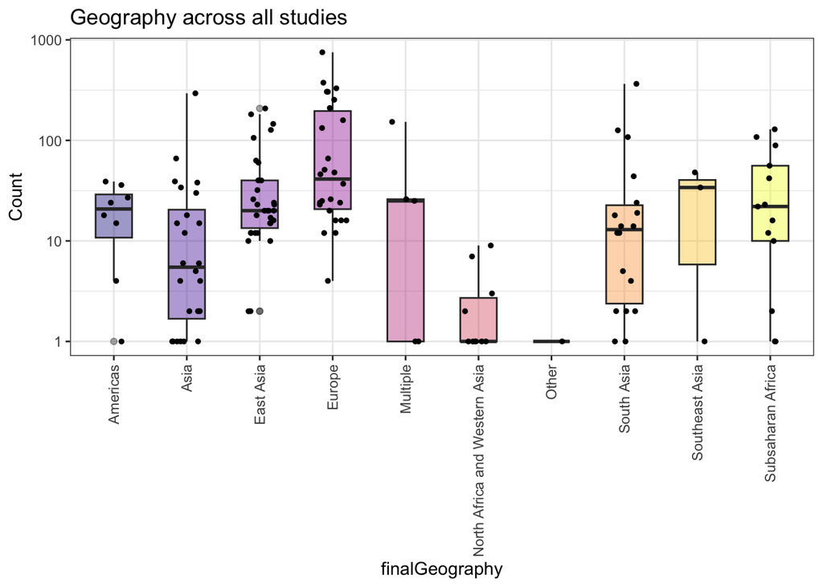

```r
# Some nice plots about this, quickly:
sampleGeography <- allSRAFinal %>% count(SRA.Study, finalGeography) %>% drop_na(finalGeography)
sampleRace <- allSRAFinal %>% count(SRA.Study, finalRace) %>% drop_na(finalRace)
meltSampleGeography <- melt(sampleGeography)
meltSampleRace <- melt(sampleRace)
ggplot(meltSampleGeography, aes(x = finalGeography, y=value,fill=finalGeography)) +
  geom_boxplot(width=0.5, alpha=0.4) +
  geom_jitter(size=1, width=0.2) +
  theme_bw() +
  ggtitle("Geography across all studies") +
  # xlab("System") +
  ylab("Count") +
  scale_y_continuous(trans='log10') +
  scale_fill_viridis(discrete=T, na.value="grey50", option="plasma") +
  theme(axis.text.x = element_text(angle = 90, vjust = 0.5, hjust=1)) +
  theme(legend.position = "none")
```

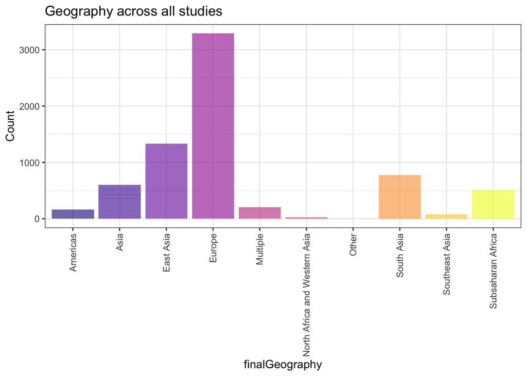

```r
ggplot(meltSampleGeography, aes(x = finalGeography, y=value,fill=finalGeography)) +
  geom_bar(stat="identity", alpha=0.6) +
  theme_bw() +
  ggtitle("Geography across all studies") +
  # xlab("System") +
  ylab("Count") +
  # scale_y_continuous(trans='log10') +
  scale_fill_viridis(discrete=T, na.value="grey50", option="plasma") +
  theme(axis.text.x = element_text(angle = 90, vjust = 0.5, hjust=1)) +
  theme(legend.position = "none")
```

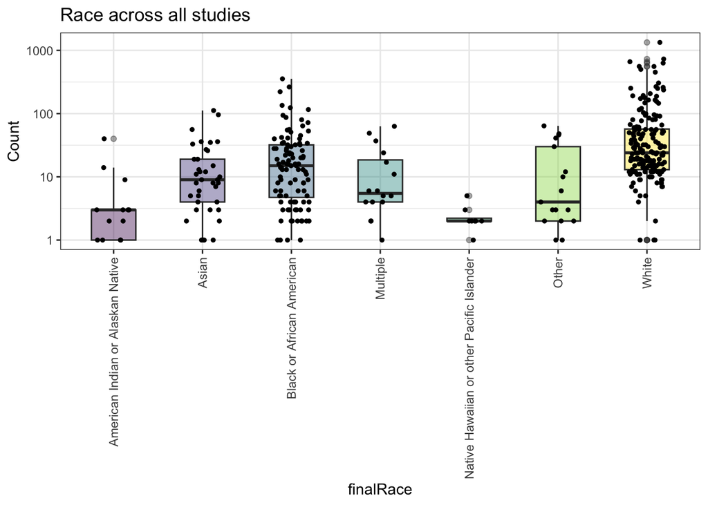

```r
ggplot(meltSampleRace, aes(x = finalRace, y=value,fill=finalRace)) +
  geom_boxplot(width=0.5, alpha=0.4) +
  geom_jitter(size=1, width=0.2) +
  theme_bw() +
  ggtitle("Race across all studies") +
  # xlab("System") +
  ylab("Count") +
  scale_y_continuous(trans='log10') +
  scale_fill_viridis(discrete=T, na.value="grey50") +
  theme(axis.text.x = element_text(angle = 90, vjust = 0.5, hjust=1)) +
  theme(legend.position = "none")
```

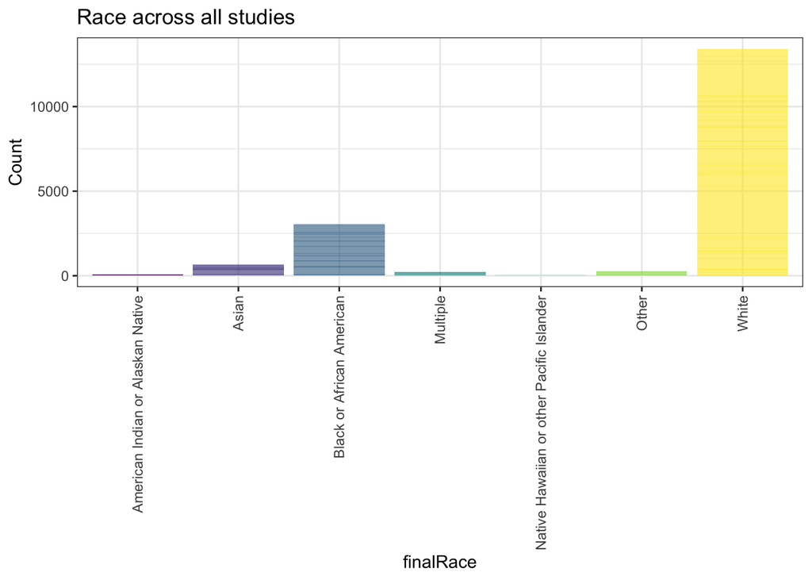

```r
ggplot(meltSampleRace, aes(x = finalRace, y=value,fill=finalRace)) +
  geom_bar(stat="identity", alpha=0.6) +
  theme_bw() +
  ggtitle("Race across all studies") +
  # xlab("System") +
  ylab("Count") +
  # scale_y_continuous(trans='log10') +
  scale_fill_viridis(discrete=T, na.value="grey50") +
  theme(axis.text.x = element_text(angle = 90, vjust = 0.5, hjust=1)) +
  theme(legend.position = "none")
```

```r
# And then cleaning out a bunch of rows that are all NA
not_all_na <- function(x) any(!is.na(x))
allSRAFinal <- allSRAFinal %>% select(where(not_all_na))
dim(allSRAFinal)
```

```
## [1] 25248    36
```

```r
saveRDS(allSRAFinal, file="20250517_allSRAAncestry.rds")
```